# PD4

1 listopada 2017

Autorzy:

- Paweł Pollak
- Karol Prusinowski
- Karol Szczawiński

# Opis danych

Dane pochodzą z artykułu [“Nadciśnienie po 40. roku życia zwiększa ryzyko demencji u kobiet”](http://naukawpolsce.pap.pl/aktualnosci/news,460010,nadcisnienie-po-40-roku-zycia-zwieksza-ryzyko-demencji-u-kobiet.html) z serwisu Nauka w Polsce.

# Sprawdzane cechy wykresów

Artykuł nie zawiera wielu danych, co pozwoliło na sprawdzenie jeszcze jednego aspektu - czy wykres jest bardziej atrakcyjny w odbiorze nawet, gdy dane można przedstawić w niedużej tabeli.

# Przygotowane formy przedstawienia danych

## Piktogram

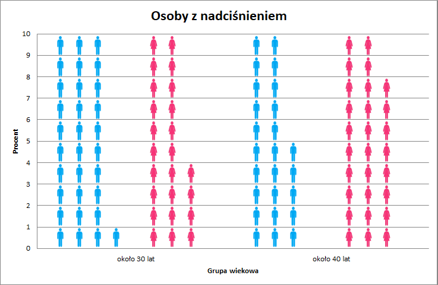

## Tabela

Procent osób z nadciśnieniem

| Wiek | Mężczyźni | Kobiety |
| --- | --- | --- |
| około 30 lat | 31 | 14 |
| około 40 lat | 25 | 18 |

## Wykres słupkowy

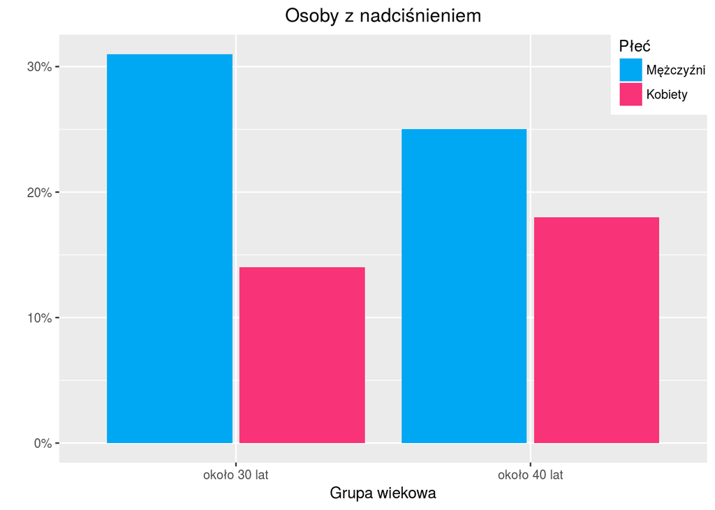

## Wykres kołowy

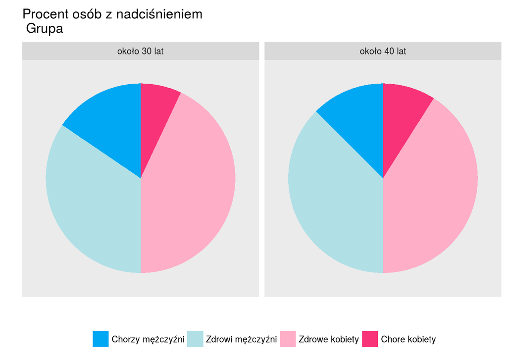

# Ankieta

Do zebrania opinii innych osób została przygotowana ankieta (dostępna pod [tym adresem](https://pp47.typeform.com/to/BSXJSe)).

### Ocena poszczególnych wykresów/tabeli

Do każdego przedstawienia danych zostały zadane dwa pytania (różne ich wariancje):

- u której płci rzadziej/częściej występuje nadciśnienie w wieku 30/40 lat
- u jakiego procentu kobiet/mężczyzn w wieku 30/40 lat występuje nadciśnienie

### Wybór najlepszych metod przedstawienia danych

Następnie, należało wybrać, które przedstawienie danych najlepiej oddało następujący opis słowny:

> Mężczyźni i kobiety mieli wykonywane pomiary ciśnienia krwi i inne testy medyczne. Okazało się, że 22 proc. osób - 31 proc. mężczyzn i 14 proc. kobiet - miało nadciśnienie tętnicze już około 30. roku życia. Po ukończeniu 40. lat odsetek ten był podobny, ale proporcje zmieniły się na niekorzyść pań, bowiem nadciśnienie stwierdzono u 25 proc. panów i 18 proc. kobiet.

I na koniec (tym razem można było wybrać kilka opcji), osoby wypełniające ankiety były proszone o wybranie tych sposobów przestawienia danych, które dobrze oddają fakt, że stosunek ryzyka występowania nadciśnienia w zależności od płci zmienia się na niekorzyść kobiet.

### Pytania:

**Wykres słupkowy:**

Pyt. 1 U której płci w wieku ok. 40 lat częściej występuje nadciśnienie?

Pyt. 2 U ilu procent kobiet w wieku ok. 30 lat występuje nadciśnienie?

**Piktogram:**

Pyt. 3 U której płci w wieku ok. 30 lat częściej występuje nadciśnienie?

Pyt. 4 U ilu procent mężczyzn w wieku ok. 30 lat występuje nadciśnienie?

**Wykres kołowy**

Pyt. 5 U której płci rzadziej występuje nadciśnienie w wieku około 30 lat?

Pyt. 6 U ilu procent kobiet w wieku ok. 40 lat występuje nadciśnienie?

**Tabela:**

Pyt. 7 U której płci rzadziej występuje nadciśnienie w wieku około 40 lat?

Pyt. 8 U ilu procent mężczyzn w wieku ok. 40 lat występuje nadciśnienie?

**Wszystkie:**

Pyt. 9 Który wykres/tabela najlepiej oddaje przedstawiony opis słowny?

Pyt. 10 Które wykresy przejrzyście przedstawią fakt, że u kobiet wraz z wiekiem zwiększa się prawdopodobieństwo nadciśnienia, a u mężczyzn zmniejsza?

# Wyniki

| Pyt. 1 | Pyt. 2 | Pyt. 3 | Pyt. 4 | Pyt. 5 | Pyt. 6 | Pyt. 7 | Pyt. 8 | Pyt. 9 | Pyt. 10 |
| --- | --- | --- | --- | --- | --- | --- | --- | --- | --- |
| u mężczyzn | 14 | u mężczyzn | 11 | u mężczyzn | 5 | u kobiet | 25 | Wykres słupkowy | Piktogram |
| u mężczyzn | 14 | u mężczyzn | 31 | u kobiet | 18 | u kobiet | 25 | Wykres słupkowy | Wykres słupkowy Piktogram Tabela |
| u mężczyzn | 14 | u mężczyzn | 31 | u kobiet | 10 | u kobiet | 25 | Wykres słupkowy | Wykres słupkowy Tabela |
| u mężczyzn | 14 | u mężczyzn | 31 | u kobiet | 10 | u kobiet | 25 | Tabela | Wykres słupkowy |
| u mężczyzn | 14 | u mężczyzn | 31 | u kobiet | 30 | u kobiet | 25 | Tabela | Wykres słupkowy Piktogram |
| u mężczyzn | 14 | u mężczyzn | 31 | u kobiet | 10 | u kobiet | 25 | Wykres słupkowy | Piktogram |
| u mężczyzn | 14 | u mężczyzn | 31 | u kobiet | 18 | u kobiet | 31 | Piktogram | Wykres słupkowy |
| u mężczyzn | 14 | u mężczyzn | 31 | u kobiet | 9 | u kobiet | 25 | Piktogram | Wykres słupkowy Piktogram |
| u mężczyzn | 14 | u mężczyzn | 31 | u kobiet | 15 | u kobiet | 25 | Tabela | Wykres słupkowy Piktogram |
| u mężczyzn | 14 | u mężczyzn | 31 | u kobiet | 10 | u kobiet | 25 | Wykres słupkowy | Piktogram |
| u mężczyzn | 14 | u mężczyzn | 31 | u kobiet | 20 | u kobiet | 25 | Tabela | Wykres słupkowy Piktogram |
| u mężczyzn | 14 | u mężczyzn | 31 | u kobiet | 23 | u kobiet | 25 | Piktogram | Wykres kołowy |
| u mężczyzn | 14 | u mężczyzn | 31 | u kobiet | 15 | u kobiet | 25 | Tabela | Wykres słupkowy Piktogram Tabela |
| u mężczyzn | 14 | u mężczyzn | 31 | u kobiet | 20 | u kobiet | 25 | Piktogram | Piktogram |
| u mężczyzn | 15 | u mężczyzn | 31 | u kobiet | 10 | u kobiet | 25 | Wykres słupkowy | Wykres słupkowy |
| u mężczyzn | 14 | u mężczyzn | 31 | u kobiet | 18 | u kobiet | 25 | Wykres słupkowy | Wykres słupkowy |
| u mężczyzn | 14 | u mężczyzn | 31 | u kobiet | 10 | u kobiet | 25 | Wykres słupkowy | Piktogram |

Można zaobserwować, że dla większości pytań 1-8 ankietowani odpowiadali poprawnie. Jedynym wyjątkiem jest pytanie o dokładny procent dla wykresu kołowego. Przeanalizowane zostało więc to pytanie oraz dane dotyczące preferencji respondentów (pytania 9 i 10).

[figure not shown]

[figure not shown]

[figure not shown]

# Podsumowanie